# Optimized Feature Selection Using Support Vector Machines with Recursive Feature Elimination and Genetic Algorithm for Detecting Coffee Adulteration via Hyperspectral Imaging: A Case for Raw Spectra

## Define the Fitness Function for GA

- This function evaluates subsets of features selected by GA using rfe with a Random Forest (svm) model.

```r
# Detect the number of cores
num_cores <- detectCores()
# Print the number of cores
print(paste("Number of cores available:", num_cores))
```

```
[1] "Number of cores available: 8"
```

```r
# Fitness Funtion
fitness_ga_rfe <- function(subset) {
  # Identify selected features based on the binary subset
  selected_features <- which(subset == 1)

  # Penalize empty subsets to avoid errors
  if (length(selected_features) == 0) return(Inf)

  # Subset the training feature matrix to selected features
  X_selected <- X_train[, selected_features]

  # Define control for rfe
  control <- rfeControl(functions = rfFuncs,  # Use Random Forest for rfe
                        method = "cv",       # Cross-validation
                        number = 10)         # 10-fold CV

  # Apply rfe to the selected subset of features
  rfe_result <- rfe(X_selected, y_train, rfeControl = control)

  # Return the negative accuracy as the fitness score (to maximize accuracy)
  return(-rfe_result$results$Accuracy[which.max(rfe_result$results$Accuracy)])
}
```

## Run the Genetic Algorithm

```r
# Set seed for reproducibility
set.seed(123)

num_features <- ncol(X_train) # Number of features
dataset_name <- "raw"   # Set the dataset name dynamically

# Define paths for the execution flag and GA result
flag_file <- paste0("ga_executed_flag_", dataset_name, ".RData")
result_file <- paste0("ga_result_", dataset_name, ".RData")

# Check if the result file exists
if (!file.exists(result_file)) {
  message("No result file found. Running the Genetic Algorithm (GA).")

  # Register cluster for caret to train the models in parallel
  cl <- makeCluster(6, type = "SOCK")
  suppressWarnings(suppressMessages(registerDoSNOW(cl)))

  # Register start time
  start_time <- Sys.time()

  # Run the Genetic Algorithm
  ga_result <- ga(
    type = "binary",
    fitness = fitness_ga_rfe,
    nBits = num_features,             # Number of features
    popSize = 20,                     # Population size
    maxiter = 50,                     # Maximum iterations
    run = 10,                         # Convergence stopping criterion
    names = colnames(train_data[, -ncol(train_data)]),  # Feature names
    pcrossover = 0.8,                 # Probability of crossover
    pmutation = 0.1,                  # Probability of mutation
    maxFitness = -0.9,                # Stop when fitness reaches target
    parallel = TRUE,                  # Enable parallel processing
    monitor = gaMonitor,              # Track progress
    seed = 123                        # Reproducibility
  )

  # Stop the cluster
  stopCluster(cl)

  # Register end time
  end_time <- Sys.time()
  print(paste('Time to run the GA model:', end_time - start_time))

  # Save the GA result and execution flag
  ga_executed <- TRUE
  save(ga_executed, ga_result, file = result_file)  # Save both flag and results

  message("GA execution completed and results saved.")

} else {
  # Load previously saved results
  message("Result file found. Loading saved GA results.")
  load(result_file)
  message(paste("GA already executed for dataset:", dataset_name))
}
```

```
Result file found. Loading saved GA results.
```

```
GA already executed for dataset: raw
```

## Visualization Plot

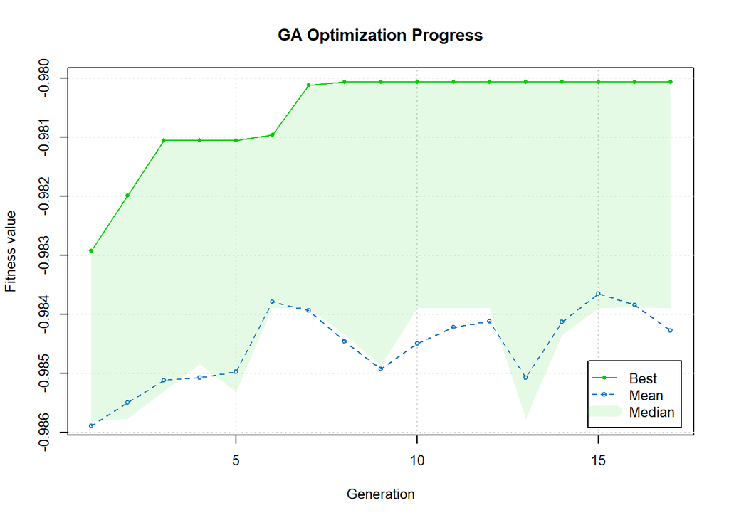

```r
par (cex = 0.8)
plot(ga_result, main = "GA Optimization Progress")
```

```r
par(cex = 1)
```

## Analyze GA results

```r
summary(ga_result)
```

```
── Genetic Algorithm ───────────────────

GA settings:
Type                  =  binary
Population size       =  20
Number of generations =  50
Elitism               =  1
Crossover probability =  0.8
Mutation probability  =  0.1

GA results:
Iterations             = 17
Fitness function value = -0.9800627
Solution =
     X935.609985 X939.059998 X942.52002 X945.97998 X949.429993 X952.890015
[1,]           0           0          0          0           1           1
     X956.349976 X959.809998 X963.27002 X966.72998  ...  X1716.650024
[1,]           0           1          0          1                  0
     X1720.22998
[1,]           0
```

## Post-Selection

```r
# Get the best feature subset
best_features <- which(ga_result@solution == 1)
selected_feature_names <- colnames(train_data)[best_features]
print(selected_feature_names)
```

```
  [1] "X949.429993"  "X952.890015"  "X959.809998"  "X966.72998"   "X973.650024"
  [6] "X977.109985"  "X980.580017"  "X984.039978"  "X990.969971"  "X994.429993"
 [11] "X1004.830017" "X1008.299988" "X1015.23999"  "X1022.179993" "X1025.650024"
 [16] "X1029.119995" "X1032.589966" "X1036.060059" "X1043"        "X1046.47998"
 [21] "X1049.949951" "X1074.290039" "X1081.23999"  "X1084.719971" "X1088.199951"
 [26] "X1095.170044" "X1098.650024" "X1102.130005" "X1105.609985" "X1109.099976"
 [31] "X1116.069946" "X1119.550049" "X1126.52002"  "X1133.5"      "X1140.469971"
 [36] "X1147.449951" "X1150.939941" "X1168.400024" "X1171.900024" "X1175.390015"
 [41] "X1182.380005" "X1185.880005" "X1189.369995" "X1203.369995" "X1213.869995"
 [46] "X1217.369995" "X1220.869995" "X1224.369995" "X1227.869995" "X1231.380005"
 [51] "X1241.890015" "X1266.439941" "X1283.98999"  "X1291.02002"  "X1294.530029"
 [56] "X1308.589966" "X1315.619995" "X1319.140015" "X1340.26001"  "X1347.300049"
 [61] "X1361.390015" "X1364.920044" "X1368.439941" "X1371.969971" "X1375.5"
 [66] "X1382.550049" "X1396.670044" "X1400.199951" "X1407.26001"  "X1414.319946"
 [71] "X1424.920044" "X1428.459961" "X1435.530029" "X1439.069946" "X1442.599976"
 [76] "X1449.680054" "X1467.380005" "X1470.920044" "X1474.459961" "X1478.01001"
 [81] "X1485.089966" "X1488.640015" "X1492.180054" "X1495.72998"  "X1499.27002"
 [86] "X1513.459961" "X1517.01001"  "X1520.560059" "X1531.209961" "X1534.76001"
 [91] "X1545.420044" "X1552.530029" "X1556.089966" "X1563.199951" "X1566.75"
 [96] "X1570.310059" "X1580.98999"  "X1591.670044" "X1602.349976" "X1605.920044"
[101] "X1609.47998"  "X1616.609985" "X1620.170044" "X1627.310059" "X1638.01001"
[106] "X1641.579956" "X1645.150024" "X1648.709961" "X1652.290039" "X1655.859985"
[111] "X1659.430054" "X1666.569946" "X1684.439941" "X1695.170044" "X1698.75"
[116] "X1702.329956" "X1705.910034" "X1709.48999"
```

```r
print(paste('The number of selected variables are', length(selected_feature_names)))
```

```
[1] "The number of selected variables are 118"
```

```r
n_selected <- as.numeric(length(selected_feature_names))
```

## Create a Data frame with the Selected Features

```r
# Subset the training and test data using the selected features
X_train_selected <- X_train[, selected_feature_names, drop = FALSE]
X_test_selected <- X_test[, selected_feature_names, drop = FALSE]

# Keep y_train and y_test as-is
y_train_selected <- y_train
y_test_selected <- y_test


#Merge data_frame
train_merged <- cbind(X_train_selected, binary_class = y_train_selected)
test_merged <- cbind(X_test_selected, binary_class = y_test_selected)

dim(train_merged)
```

```
[1] 1055  119
```

```r
dim(test_merged)
```

```
[1] 414 119
```

```r
table(train_merged$binary_class)
```

```
 adulterated pure_arabica
        1007           48
```

```r
table(test_merged$binary_class)
```

```
 adulterated pure_arabica
         387           27
```

## Create a Data frame with the Selected Features for SMOTE Data

```r
X_train_selected_smote <- X_train_smote[,selected_feature_names, drop = FALSE]
X_test_selected_smote <- X_test[, selected_feature_names, drop = FALSE]

# Keep y_train and y_test as-is
y_train_selected_smote <- y_train
y_test_selected_smote <- y_test

#Merge data_frame
train_merged_smote <- cbind(X_train_selected_smote, binary_class = smote_data$binary_class)
test_merged_smote <- cbind(X_test_selected_smote, binary_class = y_test_selected_smote)

dim(train_merged_smote)
```

```
[1] 1872  119
```

```r
dim(test_merged_smote)
```

```
[1] 414 119
```

```r
table(train_merged_smote$binary_class)
```

```
 adulterated pure_arabica
         912          960
```

```r
table(test_merged_smote$binary_class)
```

```
 adulterated pure_arabica
         387           27
```

## Check correlations by HeatMaps

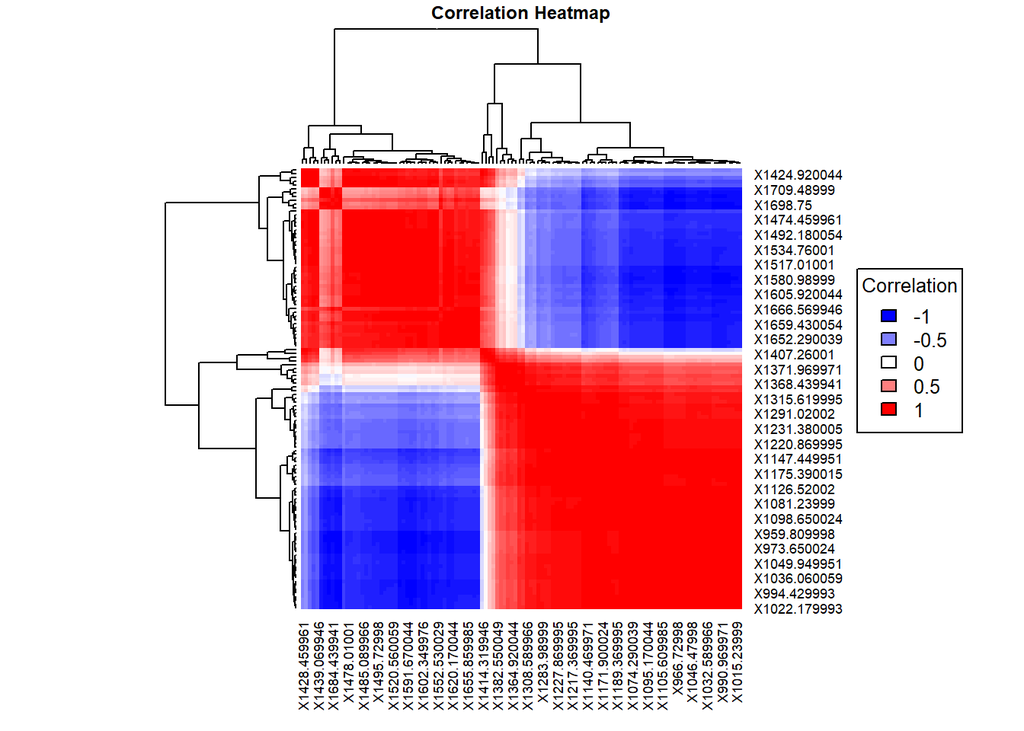

```r
# Calculate the correlation matrix

#Imbalanced Data

#Calculate correlations
corr <- cor(train_merged[, -(n_selected+1)])

# Create a heat map
par(cex.main = 0.6)
heatmap(corr, symm = TRUE,
        col = colorRampPalette(c("blue", "white", "red"))(50),
        main = "Correlation Heatmap")

# Add legend

legend("right",
       legend = seq(-1, 1, by = 0.5),  # Correlation range
       fill = colorRampPalette(c("blue", "white", "red"))(5),
       title = "Correlation", cex = 0.8)
```

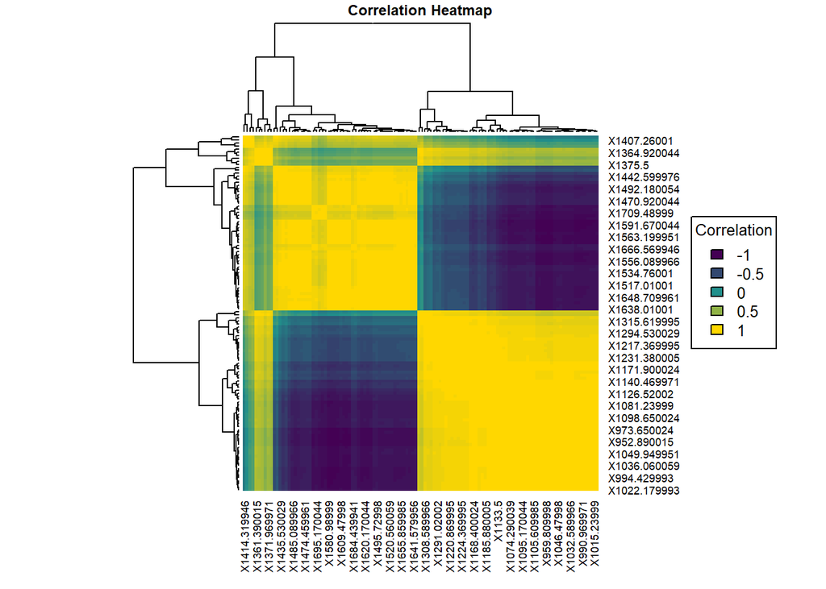

```r
# SMOTE Data
par(cex.main = 0.6)
corr <- cor(train_merged_smote[, -(n_selected+1)])
# Create heat map
heatmap(corr, symm = TRUE,
        col = colorRampPalette(c("#440154", "#21908C", "gold"))(50),
        main = 'Correlation Heatmap',cex.main = 0.6)

# Add legend
legend("right",
       legend = seq(-1, 1, by = 0.5),  # Correlation range
       fill = colorRampPalette(c("#440154", "#21908C", "gold"))(5),
       title = "Correlation",
       cex = 0.8)
```

- The correlation heat maps reveal that some variables remain highly correlated. To address this issue and mitigate multicollinearity, we will employ Principal Component Analysis (PCA)

## PreProcess by PCA, Centering and Scaling Data

```r
# Imbalanced Data
pca_Preprocess <- preProcess(train_merged, method = c("center", "scale", "pca"))
train_mergedPreprocessed <- predict(pca_Preprocess, train_merged) # train data
test_mergedPreprocessed <- predict(pca_Preprocess,test_merged) # apply on test data

# SMOTE Data
pca_Preprocess_smote <- preProcess(train_merged_smote,method = c("center", "scale", "pca"))
train_merged_smote_Preprocessed <- predict(pca_Preprocess_smote,train_merged_smote)
test_merged_smote_Preprocessed <- predict(pca_Preprocess_smote,test_merged_smote)

# Check dimensions of the preprocessed data to ensure consistency

dim(train_mergedPreprocessed)
```

```
[1] 1055    3
```

```r
dim(test_mergedPreprocessed)
```

```
[1] 414   3
```

```r
dim(train_merged_smote_Preprocessed)
```

```
[1] 1872    3
```

```r
dim(test_merged_smote_Preprocessed)
```

```
[1] 414   3
```

## Train Models

### Support Vector Machines (SVM)

- We will train SVM model using sparse variables selected by the RFE and GA algorithms, further reduced through Principal Component Analysis (PCA).

## Set Up Training Parameters

```r
# Set random seed for reproducibility

set.seed (123)

# Set up the training control(10 folds 10 times cross_validation)
control <- trainControl(method = "repeatedcv", number = 10, repeats = 10,
                        classProbs = TRUE, savePredictions = "final",
                        summaryFunction = multiClassSummary,
                        selectionFunction = 'oneSE', allowParallel = TRUE)

# OneSE rule will be used to select simplest yet optimal model within the 'best model'
```

```r
#Set the metric as accuracy
metric<-"Accuracy"
```

```r
# Hyperparameter Tuning
# We will use tuneLength to automatically determine the optimal parameters Cost (C) and  RBF kernel γ parameter
```

## Train the Models

```r
#Register cluster for caret to train the models in parallel
cl<-makeCluster(6,type = "SOCK")
suppressWarnings(suppressMessages(
  registerDoSNOW(cl)))

# Start_time
start_time<-Sys.time()

#Train the model using cross-validation (10 folds, 10 times)
fit_svm_raw<-train(as.factor(binary_class) ~.,
                         data = train_mergedPreprocessed,
                         method = 'svmRadial', tuneLength =  10,
                         trControl = control,
                         metric = 'Accuracy') #unmodified data
#End_time
end_time<-Sys.time()

model_training_time<-end_time-start_time

stopCluster(cl) # Stop the parallel run cluster

print(model_training_time)
```

```
Time difference of 37.79091 secs
```

```r
#Register cluster for caret to train the models in parallel
cl<-makeCluster(6,type = "SOCK")
suppressWarnings(suppressMessages(
  registerDoSNOW(cl)))

# Start_time
start_time<-Sys.time()
fit_svm_smote_raw <- train(as.factor(binary_class) ~., data = train_merged_smote_Preprocessed,
                         method = 'svmRadial', tuneLength = 10,
                         trControl = control,
                         metric = 'Accuracy') # SMOTE data

#End_time
end_time<-Sys.time()

model_training_time<-end_time-start_time

stopCluster(cl) # Stop the parallel run cluster

print(model_training_time)
```

```
Time difference of 1.419347 mins
```

```r
# Display model results for imbalanced data
print(fit_svm_raw)
```

```
Support Vector Machines with Radial Basis Function Kernel

1055 samples
   2 predictor
   2 classes: 'adulterated', 'pure_arabica'

No pre-processing
Resampling: Cross-Validated (10 fold, repeated 10 times)
Summary of sample sizes: 949, 949, 949, 950, 949, 950, ...
Resampling results across tuning parameters:

  C       logLoss    AUC        prAUC      Accuracy   Kappa      F1
    0.25  0.1454150  0.7780844  0.6826771  0.9605801  0.3739673  0.9795991
    0.50  0.1420641  0.7779520  0.6827138  0.9613339  0.3870346  0.9799899
    1.00  0.1355469  0.7780600  0.6829153  0.9629503  0.3932852  0.9808546
    2.00  0.1370477  0.7853844  0.6825757  0.9610527  0.3458259  0.9798880
    4.00  0.1355279  0.8154531  0.6907728  0.9610536  0.3484987  0.9798893
    8.00  0.1349808  0.8345715  0.6936141  0.9606753  0.3166767  0.9797196
   16.00  0.1415378  0.8301315  0.6845304  0.9591551  0.2733964  0.9789514
   32.00  0.1458386  0.8295039  0.6795822  0.9576412  0.2227581  0.9781942
   64.00  0.1505505  0.8278726  0.6736452  0.9574516  0.2137370  0.9780955
  128.00  0.1510257  0.8270357  0.6726008  0.9568802  0.1901869  0.9778163
  Sensitivity  Specificity  Pos_Pred_Value  Neg_Pred_Value  Precision
  0.9918594    0.3060       0.9677413       0.7058608       0.9677413
  0.9923584    0.3115       0.9680258       0.7227599       0.9680258
  0.9941465    0.3100       0.9679942       0.7567029       0.9679942
  0.9940416    0.2720       0.9662348       0.7340909       0.9662348
  0.9939416    0.2735       0.9663100       0.7142593       0.9663100
  0.9949347    0.2440       0.9650425       0.7285714       0.9650425
  0.9949356    0.2110       0.9635619       0.7025974       0.9635619
  0.9953317    0.1700       0.9617240       0.6828431       0.9617240
  0.9952317    0.1670       0.9616335       0.6701058       0.9616335
  0.9955297    0.1480       0.9608101       0.6311475       0.9608101
  Recall     Detection_Rate  Balanced_Accuracy
  0.9918594  0.9467426       0.6489297
  0.9923584  0.9472161       0.6519292
  0.9941465  0.9489250       0.6520733
  0.9940416  0.9488243       0.6330208
  0.9939416  0.9487309       0.6337208
  0.9949347  0.9496806       0.6194673
  0.9949356  0.9496788       0.6029678
  0.9953317  0.9500570       0.5826658
  0.9952317  0.9499636       0.5811158
  0.9955297  0.9502466       0.5717649

Tuning parameter 'sigma' was held constant at a value of 1.576075
Accuracy was used to select the optimal model using  the one SE rule.
The final values used for the model were sigma = 1.576075 and C = 1.
```

```r
# Display results for data balanced by SMOTE
print(fit_svm_smote_raw)
```

```
Support Vector Machines with Radial Basis Function Kernel

1872 samples
   2 predictor
   2 classes: 'adulterated', 'pure_arabica'

No pre-processing
Resampling: Cross-Validated (10 fold, repeated 10 times)
Summary of sample sizes: 1685, 1684, 1685, 1685, 1685, 1685, ...
Resampling results across tuning parameters:

  C       logLoss    AUC        prAUC      Accuracy   Kappa      F1
    0.25  0.1613140  0.9750687  0.9626640  0.9427876  0.8853129  0.9392885
    0.50  0.1592923  0.9768631  0.9645341  0.9446578  0.8890639  0.9412934
    1.00  0.1572453  0.9779831  0.9656826  0.9466350  0.8930234  0.9433504
    2.00  0.1561063  0.9779609  0.9656130  0.9496257  0.8990275  0.9466262
    4.00  0.1531698  0.9783973  0.9654499  0.9521368  0.9040494  0.9491581
    8.00  0.1516059  0.9786454  0.9642850  0.9532049  0.9061664  0.9500272
   16.00  0.1497388  0.9788261  0.9644078  0.9520321  0.9038062  0.9486733
   32.00  0.1455107  0.9793831  0.9655899  0.9525668  0.9048838  0.9493035
   64.00  0.1436465  0.9796424  0.9664433  0.9527805  0.9053133  0.9495419
  128.00  0.1415042  0.9802177  0.9671613  0.9523527  0.9044577  0.9491126
  Sensitivity  Specificity  Pos_Pred_Value  Neg_Pred_Value  Precision
  0.9112960    0.9727083    0.9696998       0.9209125       0.9696998
  0.9137100    0.9740625    0.9712683       0.9230401       0.9712683
  0.9152449    0.9764583    0.9738727       0.9244767       0.9738727
  0.9198471    0.9779167    0.9755931       0.9283550       0.9755931
  0.9202879    0.9823958    0.9805110       0.9290471       0.9805110
  0.9172157    0.9873958    0.9859229       0.9269065       0.9859229
  0.9144828    0.9877083    0.9862423       0.9247511       0.9862423
  0.9152508    0.9880208    0.9865954       0.9252732       0.9865954
  0.9160201    0.9877083    0.9862452       0.9259295       0.9862452
  0.9157979    0.9870833    0.9855687       0.9256812       0.9855687
  Recall     Detection_Rate  Balanced_Accuracy
  0.9112960  0.4439621       0.9420022
  0.9137100  0.4451377       0.9438862
  0.9152449  0.4458855       0.9458516
  0.9198471  0.4481283       0.9488819
  0.9202879  0.4483425       0.9513418
  0.9172157  0.4468463       0.9523058
  0.9144828  0.4455129       0.9510956
  0.9152508  0.4458869       0.9516358
  0.9160201  0.4462612       0.9518642
  0.9157979  0.4461537       0.9514406

Tuning parameter 'sigma' was held constant at a value of 1.515451
Accuracy was used to select the optimal model using  the one SE rule.
The final values used for the model were sigma = 1.515451 and C = 4.
```

## Save the models for future use

```r
saveRDS(fit_svm_raw, "fit_svm_raw.rds")
saveRDS(fit_svm_smote_raw, "fit_svm_smote_raw.rds")
```

## Plot the cross-validation results —-> Model selection

```r
# Imbalanced Data
fit_svm_raw
```

```
Support Vector Machines with Radial Basis Function Kernel

1055 samples
   2 predictor
   2 classes: 'adulterated', 'pure_arabica'

No pre-processing
Resampling: Cross-Validated (10 fold, repeated 10 times)
Summary of sample sizes: 949, 949, 949, 950, 949, 950, ...
Resampling results across tuning parameters:

  C       logLoss    AUC        prAUC      Accuracy   Kappa      F1
    0.25  0.1454150  0.7780844  0.6826771  0.9605801  0.3739673  0.9795991
    0.50  0.1420641  0.7779520  0.6827138  0.9613339  0.3870346  0.9799899
    1.00  0.1355469  0.7780600  0.6829153  0.9629503  0.3932852  0.9808546
    2.00  0.1370477  0.7853844  0.6825757  0.9610527  0.3458259  0.9798880
    4.00  0.1355279  0.8154531  0.6907728  0.9610536  0.3484987  0.9798893
    8.00  0.1349808  0.8345715  0.6936141  0.9606753  0.3166767  0.9797196
   16.00  0.1415378  0.8301315  0.6845304  0.9591551  0.2733964  0.9789514
   32.00  0.1458386  0.8295039  0.6795822  0.9576412  0.2227581  0.9781942
   64.00  0.1505505  0.8278726  0.6736452  0.9574516  0.2137370  0.9780955
  128.00  0.1510257  0.8270357  0.6726008  0.9568802  0.1901869  0.9778163
  Sensitivity  Specificity  Pos_Pred_Value  Neg_Pred_Value  Precision
  0.9918594    0.3060       0.9677413       0.7058608       0.9677413
  0.9923584    0.3115       0.9680258       0.7227599       0.9680258
  0.9941465    0.3100       0.9679942       0.7567029       0.9679942
  0.9940416    0.2720       0.9662348       0.7340909       0.9662348
  0.9939416    0.2735       0.9663100       0.7142593       0.9663100
  0.9949347    0.2440       0.9650425       0.7285714       0.9650425
  0.9949356    0.2110       0.9635619       0.7025974       0.9635619
  0.9953317    0.1700       0.9617240       0.6828431       0.9617240
  0.9952317    0.1670       0.9616335       0.6701058       0.9616335
  0.9955297    0.1480       0.9608101       0.6311475       0.9608101
  Recall     Detection_Rate  Balanced_Accuracy
  0.9918594  0.9467426       0.6489297
  0.9923584  0.9472161       0.6519292
  0.9941465  0.9489250       0.6520733
  0.9940416  0.9488243       0.6330208
  0.9939416  0.9487309       0.6337208
  0.9949347  0.9496806       0.6194673
  0.9949356  0.9496788       0.6029678
  0.9953317  0.9500570       0.5826658
  0.9952317  0.9499636       0.5811158
  0.9955297  0.9502466       0.5717649

Tuning parameter 'sigma' was held constant at a value of 1.576075
Accuracy was used to select the optimal model using  the one SE rule.
The final values used for the model were sigma = 1.576075 and C = 1.
```

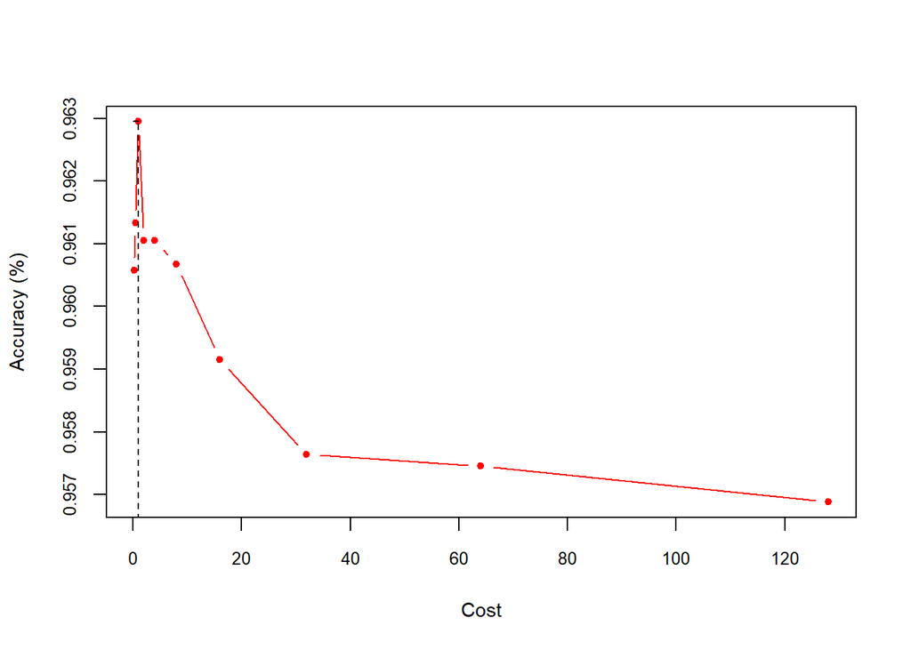

```r
C_data<-fit_svm_raw$results
best_C = fit_svm_raw$bestTune$C
y_Acc = C_data$Accuracy[C_data$C == best_C]
plot(C_data$C,C_data$Accuracy, type = "b",col = "red",pch = 20,cex.axis = 0.8,
     xlab = "Cost", ylab = "Accuracy (%)",cex.lab = 0.9)
# Add line from x-axis to the specific point
segments(x0 = best_C, y0 = 0, x1 = best_C, y1 = y_Acc, col = "black", lty = 2)

# Add line from y-axis to the specific point
segments(x0 = 0, y0 = y_Acc, x1 = best_C, y1 = y_Acc, col = "black", lty = 2)
```

```r
# Balanced Data
fit_svm_smote_raw
```

```
Support Vector Machines with Radial Basis Function Kernel

1872 samples
   2 predictor
   2 classes: 'adulterated', 'pure_arabica'

No pre-processing
Resampling: Cross-Validated (10 fold, repeated 10 times)
Summary of sample sizes: 1685, 1684, 1685, 1685, 1685, 1685, ...
Resampling results across tuning parameters:

  C       logLoss    AUC        prAUC      Accuracy   Kappa      F1
    0.25  0.1613140  0.9750687  0.9626640  0.9427876  0.8853129  0.9392885
    0.50  0.1592923  0.9768631  0.9645341  0.9446578  0.8890639  0.9412934
    1.00  0.1572453  0.9779831  0.9656826  0.9466350  0.8930234  0.9433504
    2.00  0.1561063  0.9779609  0.9656130  0.9496257  0.8990275  0.9466262
    4.00  0.1531698  0.9783973  0.9654499  0.9521368  0.9040494  0.9491581
    8.00  0.1516059  0.9786454  0.9642850  0.9532049  0.9061664  0.9500272
   16.00  0.1497388  0.9788261  0.9644078  0.9520321  0.9038062  0.9486733
   32.00  0.1455107  0.9793831  0.9655899  0.9525668  0.9048838  0.9493035
   64.00  0.1436465  0.9796424  0.9664433  0.9527805  0.9053133  0.9495419
  128.00  0.1415042  0.9802177  0.9671613  0.9523527  0.9044577  0.9491126
  Sensitivity  Specificity  Pos_Pred_Value  Neg_Pred_Value  Precision
  0.9112960    0.9727083    0.9696998       0.9209125       0.9696998
  0.9137100    0.9740625    0.9712683       0.9230401       0.9712683
  0.9152449    0.9764583    0.9738727       0.9244767       0.9738727
  0.9198471    0.9779167    0.9755931       0.9283550       0.9755931
  0.9202879    0.9823958    0.9805110       0.9290471       0.9805110
  0.9172157    0.9873958    0.9859229       0.9269065       0.9859229
  0.9144828    0.9877083    0.9862423       0.9247511       0.9862423
  0.9152508    0.9880208    0.9865954       0.9252732       0.9865954
  0.9160201    0.9877083    0.9862452       0.9259295       0.9862452
  0.9157979    0.9870833    0.9855687       0.9256812       0.9855687
  Recall     Detection_Rate  Balanced_Accuracy
  0.9112960  0.4439621       0.9420022
  0.9137100  0.4451377       0.9438862
  0.9152449  0.4458855       0.9458516
  0.9198471  0.4481283       0.9488819
  0.9202879  0.4483425       0.9513418
  0.9172157  0.4468463       0.9523058
  0.9144828  0.4455129       0.9510956
  0.9152508  0.4458869       0.9516358
  0.9160201  0.4462612       0.9518642
  0.9157979  0.4461537       0.9514406

Tuning parameter 'sigma' was held constant at a value of 1.515451
Accuracy was used to select the optimal model using  the one SE rule.
The final values used for the model were sigma = 1.515451 and C = 4.
```

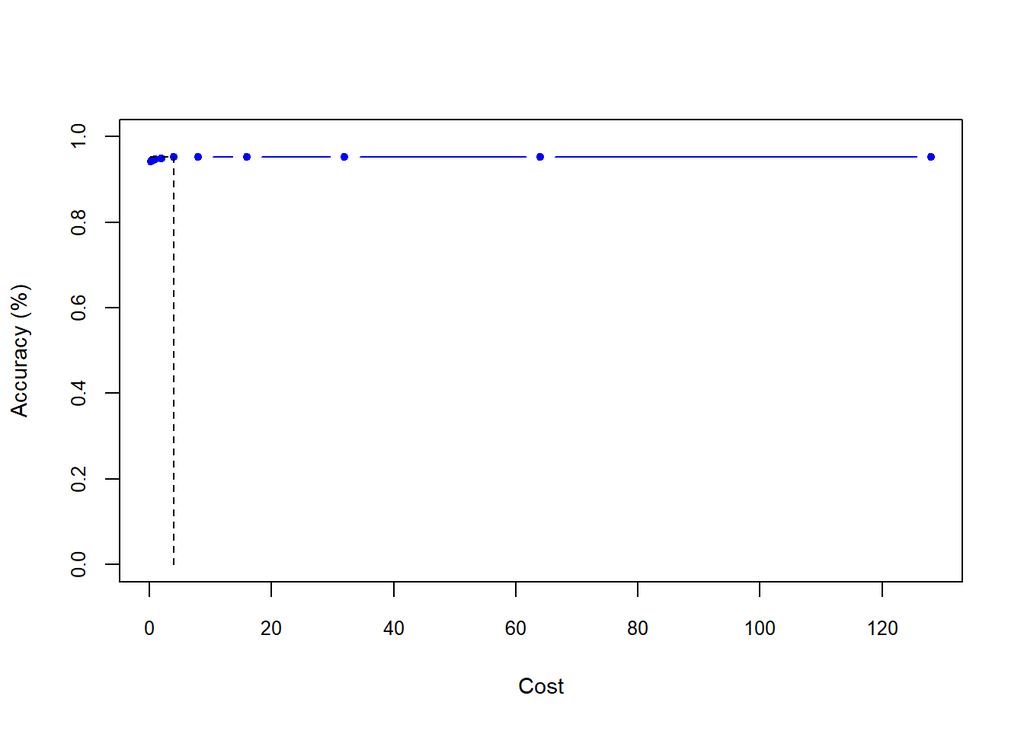

```r
C_data<-fit_svm_smote_raw$results
best_C = fit_svm_smote_raw$bestTune$C
y_Acc = C_data$Accuracy[C_data$C == best_C]
plot(C_data$C,C_data$Accuracy, type = "b",col = "blue",pch = 20,cex.axis = 0.8,
     xlab = "Cost", ylab = "Accuracy (%)",cex.lab = 0.9,ylim = c(0,1))
# Add line from x-axis to the specific point
segments(x0 = best_C, y0 = 0, x1 = best_C, y1 = y_Acc, col = "black", lty = 2)

# Add line from y-axis to the specific point
segments(x0 = 0, y0 = y_Acc, x1 = best_C, y1 = y_Acc, col = "black", lty = 2)
```

## Display the cross-validation results

```r
print(paste('The optimal parametrers for training the SVM model are sigma value of', round(as.numeric(fit_svm_raw$bestTune$sigma),2), 'and Cost parameter of', fit_svm_raw$bestTune$C)) # unmodified data
```

```
[1] "The optimal parametrers for training the SVM model are sigma value of 1.58 and Cost parameter of 1"
```

```r
print(paste('The optimal parametrers for training the SVM model are sigma value of', round(as.numeric(fit_svm_smote_raw$bestTune$sigma),2), 'and Cost parameter of', fit_svm_smote_raw$bestTune$C)) # SMOTE data
```

```
[1] "The optimal parametrers for training the SVM model are sigma value of 1.52 and Cost parameter of 4"
```

## Display CV results in Tables

```r
# Imbalanced data
kable(fit_svm_raw$results, caption = "SVM Cross-validation Results")
```

SVM Cross-validation Results

| sigma | C | logLoss | AUC | prAUC | Accuracy | Kappa | F1 | Sensitivity | Specificity | Pos_Pred_Value | Neg_Pred_Value | Precision | Recall | Detection_Rate | Balanced_Accuracy | logLossSD | AUCSD | prAUCSD | AccuracySD | KappaSD | F1SD | SensitivitySD | SpecificitySD | Pos_Pred_ValueSD | Neg_Pred_ValueSD | PrecisionSD | RecallSD | Detection_RateSD | Balanced_AccuracySD |
| --- | --- | --- | --- | --- | --- | --- | --- | --- | --- | --- | --- | --- | --- | --- | --- | --- | --- | --- | --- | --- | --- | --- | --- | --- | --- | --- | --- | --- | --- |
| 1.576075 | 0.25 | 0.1454150 | 0.7780844 | 0.6826771 | 0.9605801 | 0.3739673 | 0.9795991 | 0.9918594 | 0.3060 | 0.9677413 | 0.7058608 | 0.9677413 | 0.9918594 | 0.9467426 | 0.6489297 | 0.0421819 | 0.1538214 | 0.0943799 | 0.0127967 | 0.2215524 | 0.0066647 | 0.0101109 | 0.1992765 | 0.0095320 | 0.3154888 | 0.0095320 | 0.0101109 | 0.0100853 | 0.0992234 |
| 1.576075 | 0.50 | 0.1420641 | 0.7779520 | 0.6827138 | 0.9613339 | 0.3870346 | 0.9799899 | 0.9923584 | 0.3115 | 0.9680258 | 0.7227599 | 0.9680258 | 0.9923584 | 0.9472161 | 0.6519292 | 0.0397571 | 0.1538667 | 0.0941590 | 0.0116171 | 0.2032989 | 0.0060546 | 0.0099486 | 0.1820000 | 0.0086819 | 0.2977247 | 0.0086819 | 0.0099486 | 0.0096736 | 0.0903052 |
| 1.576075 | 1.00 | 0.1355469 | 0.7780600 | 0.6829153 | 0.9629503 | 0.3932852 | 0.9808546 | 0.9941465 | 0.3100 | 0.9679942 | 0.7567029 | 0.9679942 | 0.9941465 | 0.9489250 | 0.6520733 | 0.0366710 | 0.1574802 | 0.0959204 | 0.0112380 | 0.2161170 | 0.0058111 | 0.0078587 | 0.1926687 | 0.0093062 | 0.2930416 | 0.0093062 | 0.0078587 | 0.0079735 | 0.0959714 |
| 1.576075 | 2.00 | 0.1370477 | 0.7853844 | 0.6825757 | 0.9610527 | 0.3458259 | 0.9798880 | 0.9940416 | 0.2720 | 0.9662348 | 0.7340909 | 0.9662348 | 0.9940416 | 0.9488243 | 0.6330208 | 0.0344419 | 0.1542251 | 0.0955179 | 0.0106519 | 0.2176832 | 0.0055090 | 0.0085847 | 0.1941467 | 0.0095037 | 0.3203135 | 0.0095037 | 0.0085847 | 0.0085809 | 0.0959014 |
| 1.576075 | 4.00 | 0.1355279 | 0.8154531 | 0.6907728 | 0.9610536 | 0.3484987 | 0.9798893 | 0.9939416 | 0.2735 | 0.9663100 | 0.7142593 | 0.9663100 | 0.9939416 | 0.9487309 | 0.6337208 | 0.0338614 | 0.1482915 | 0.0905928 | 0.0102154 | 0.2132806 | 0.0052723 | 0.0073219 | 0.1857900 | 0.0091150 | 0.3189555 | 0.0091150 | 0.0073219 | 0.0076858 | 0.0921219 |
| 1.576075 | 8.00 | 0.1349808 | 0.8345715 | 0.6936141 | 0.9606753 | 0.3166767 | 0.9797196 | 0.9949347 | 0.2440 | 0.9650425 | 0.7285714 | 0.9650425 | 0.9949347 | 0.9496806 | 0.6194673 | 0.0302892 | 0.1382947 | 0.0839527 | 0.0104373 | 0.2264078 | 0.0053735 | 0.0069875 | 0.1924431 | 0.0093988 | 0.3433395 | 0.0093988 | 0.0069875 | 0.0076251 | 0.0954899 |
| 1.576075 | 16.00 | 0.1415378 | 0.8301315 | 0.6845304 | 0.9591551 | 0.2733964 | 0.9789514 | 0.9949356 | 0.2110 | 0.9635619 | 0.7025974 | 0.9635619 | 0.9949356 | 0.9496788 | 0.6029678 | 0.0323283 | 0.1398024 | 0.0834597 | 0.0101268 | 0.2260191 | 0.0052139 | 0.0074025 | 0.1916937 | 0.0094328 | 0.3520415 | 0.0094328 | 0.0074025 | 0.0076445 | 0.0948212 |
| 1.576075 | 32.00 | 0.1458386 | 0.8295039 | 0.6795822 | 0.9576412 | 0.2227581 | 0.9781942 | 0.9953317 | 0.1700 | 0.9617240 | 0.6828431 | 0.9617240 | 0.9953317 | 0.9500570 | 0.5826658 | 0.0317204 | 0.1400059 | 0.0821509 | 0.0089498 | 0.2102107 | 0.0046079 | 0.0071280 | 0.1746570 | 0.0089023 | 0.3553193 | 0.0089023 | 0.0071280 | 0.0074278 | 0.0859088 |
| 1.576075 | 64.00 | 0.1505505 | 0.8278726 | 0.6736452 | 0.9574516 | 0.2137370 | 0.9780955 | 0.9952317 | 0.1670 | 0.9616335 | 0.6701058 | 0.9616335 | 0.9952317 | 0.9499636 | 0.5811158 | 0.0337930 | 0.1311841 | 0.0783866 | 0.0098267 | 0.2249337 | 0.0050786 | 0.0077979 | 0.1875170 | 0.0092363 | 0.3548582 | 0.0092363 | 0.0077979 | 0.0082578 | 0.0923787 |
| 1.576075 | 128.00 | 0.1510257 | 0.8270357 | 0.6726008 | 0.9568802 | 0.1901869 | 0.9778163 | 0.9955297 | 0.1480 | 0.9608101 | 0.6311475 | 0.9608101 | 0.9955297 | 0.9502466 | 0.5717649 | 0.0334907 | 0.1311187 | 0.0818548 | 0.0097272 | 0.2220293 | 0.0050167 | 0.0073903 | 0.1850362 | 0.0091652 | 0.3866700 | 0.0091652 | 0.0073903 | 0.0077391 | 0.0913015 |

```r
# Select the best results row # unmodified data
selected_row <- fit_svm_raw$results %>%
  filter(C==fit_svm_raw$bestTune$C & sigma == fit_svm_raw$bestTune$sigma)

kable(selected_row)
```

| sigma | C | logLoss | AUC | prAUC | Accuracy | Kappa | F1 | Sensitivity | Specificity | Pos_Pred_Value | Neg_Pred_Value | Precision | Recall | Detection_Rate | Balanced_Accuracy | logLossSD | AUCSD | prAUCSD | AccuracySD | KappaSD | F1SD | SensitivitySD | SpecificitySD | Pos_Pred_ValueSD | Neg_Pred_ValueSD | PrecisionSD | RecallSD | Detection_RateSD | Balanced_AccuracySD |
| --- | --- | --- | --- | --- | --- | --- | --- | --- | --- | --- | --- | --- | --- | --- | --- | --- | --- | --- | --- | --- | --- | --- | --- | --- | --- | --- | --- | --- | --- |
| 1.576075 | 1 | 0.1355469 | 0.77806 | 0.6829153 | 0.9629503 | 0.3932852 | 0.9808546 | 0.9941465 | 0.31 | 0.9679942 | 0.7567029 | 0.9679942 | 0.9941465 | 0.948925 | 0.6520733 | 0.036671 | 0.1574802 | 0.0959204 | 0.011238 | 0.216117 | 0.0058111 | 0.0078587 | 0.1926687 | 0.0093062 | 0.2930416 | 0.0093062 | 0.0078587 | 0.0079735 | 0.0959714 |

```r
# SMOTE Data
kable(fit_svm_smote_raw$results, caption = "SVM SMOTE Cross-validation Results")
```

SVM SMOTE Cross-validation Results

| sigma | C | logLoss | AUC | prAUC | Accuracy | Kappa | F1 | Sensitivity | Specificity | Pos_Pred_Value | Neg_Pred_Value | Precision | Recall | Detection_Rate | Balanced_Accuracy | logLossSD | AUCSD | prAUCSD | AccuracySD | KappaSD | F1SD | SensitivitySD | SpecificitySD | Pos_Pred_ValueSD | Neg_Pred_ValueSD | PrecisionSD | RecallSD | Detection_RateSD | Balanced_AccuracySD |
| --- | --- | --- | --- | --- | --- | --- | --- | --- | --- | --- | --- | --- | --- | --- | --- | --- | --- | --- | --- | --- | --- | --- | --- | --- | --- | --- | --- | --- | --- |
| 1.515451 | 0.25 | 0.1613140 | 0.9750687 | 0.9626640 | 0.9427876 | 0.8853129 | 0.9392885 | 0.9112960 | 0.9727083 | 0.9696998 | 0.9209125 | 0.9696998 | 0.9112960 | 0.4439621 | 0.9420022 | 0.0367689 | 0.0110910 | 0.0123626 | 0.0170451 | 0.0342135 | 0.0185813 | 0.0299861 | 0.0163386 | 0.0175872 | 0.0250599 | 0.0175872 | 0.0299861 | 0.0146232 | 0.0172798 |
| 1.515451 | 0.50 | 0.1592923 | 0.9768631 | 0.9645341 | 0.9446578 | 0.8890639 | 0.9412934 | 0.9137100 | 0.9740625 | 0.9712683 | 0.9230401 | 0.9712683 | 0.9137100 | 0.4451377 | 0.9438862 | 0.0374546 | 0.0108568 | 0.0122949 | 0.0168762 | 0.0338742 | 0.0183976 | 0.0302452 | 0.0163194 | 0.0175558 | 0.0253097 | 0.0175558 | 0.0302452 | 0.0147365 | 0.0171180 |
| 1.515451 | 1.00 | 0.1572453 | 0.9779831 | 0.9656826 | 0.9466350 | 0.8930234 | 0.9433504 | 0.9152449 | 0.9764583 | 0.9738727 | 0.9244767 | 0.9738727 | 0.9152449 | 0.4458855 | 0.9458516 | 0.0371557 | 0.0108907 | 0.0123414 | 0.0165100 | 0.0331420 | 0.0180296 | 0.0299657 | 0.0149983 | 0.0162029 | 0.0251399 | 0.0162029 | 0.0299657 | 0.0146035 | 0.0167650 |
| 1.515451 | 2.00 | 0.1561063 | 0.9779609 | 0.9656130 | 0.9496257 | 0.8990275 | 0.9466262 | 0.9198471 | 0.9779167 | 0.9755931 | 0.9283550 | 0.9755931 | 0.9198471 | 0.4481283 | 0.9488819 | 0.0367918 | 0.0108787 | 0.0120043 | 0.0158684 | 0.0318449 | 0.0172214 | 0.0283899 | 0.0151191 | 0.0163116 | 0.0240238 | 0.0163116 | 0.0283899 | 0.0138602 | 0.0160978 |
| 1.515451 | 4.00 | 0.1531698 | 0.9783973 | 0.9654499 | 0.9521368 | 0.9040494 | 0.9491581 | 0.9202879 | 0.9823958 | 0.9805110 | 0.9290471 | 0.9805110 | 0.9202879 | 0.4483425 | 0.9513418 | 0.0365828 | 0.0109076 | 0.0125802 | 0.0153581 | 0.0308263 | 0.0167401 | 0.0285498 | 0.0143313 | 0.0155794 | 0.0239978 | 0.0155794 | 0.0285498 | 0.0139232 | 0.0156045 |
| 1.515451 | 8.00 | 0.1516059 | 0.9786454 | 0.9642850 | 0.9532049 | 0.9061664 | 0.9500272 | 0.9172157 | 0.9873958 | 0.9859229 | 0.9269065 | 0.9859229 | 0.9172157 | 0.4468463 | 0.9523058 | 0.0364581 | 0.0111272 | 0.0140474 | 0.0161131 | 0.0323593 | 0.0177585 | 0.0305466 | 0.0125887 | 0.0138794 | 0.0253406 | 0.0138794 | 0.0305466 | 0.0149105 | 0.0164131 |
| 1.515451 | 16.00 | 0.1497388 | 0.9788261 | 0.9644078 | 0.9520321 | 0.9038062 | 0.9486733 | 0.9144828 | 0.9877083 | 0.9862423 | 0.9247511 | 0.9862423 | 0.9144828 | 0.4455129 | 0.9510956 | 0.0368144 | 0.0112464 | 0.0143894 | 0.0166148 | 0.0333707 | 0.0183686 | 0.0321010 | 0.0125088 | 0.0137697 | 0.0265991 | 0.0137697 | 0.0321010 | 0.0156057 | 0.0169378 |
| 1.515451 | 32.00 | 0.1455107 | 0.9793831 | 0.9655899 | 0.9525668 | 0.9048838 | 0.9493035 | 0.9152508 | 0.9880208 | 0.9865954 | 0.9252732 | 0.9865954 | 0.9152508 | 0.4458869 | 0.9516358 | 0.0356565 | 0.0108154 | 0.0134411 | 0.0155411 | 0.0312054 | 0.0170913 | 0.0293208 | 0.0125083 | 0.0137877 | 0.0244041 | 0.0137877 | 0.0293208 | 0.0142456 | 0.0158150 |
| 1.515451 | 64.00 | 0.1436465 | 0.9796424 | 0.9664433 | 0.9527805 | 0.9053133 | 0.9495419 | 0.9160201 | 0.9877083 | 0.9862452 | 0.9259295 | 0.9862452 | 0.9160201 | 0.4462612 | 0.9518642 | 0.0354411 | 0.0106030 | 0.0126422 | 0.0156404 | 0.0314072 | 0.0172301 | 0.0301432 | 0.0118796 | 0.0130808 | 0.0251502 | 0.0130808 | 0.0301432 | 0.0146356 | 0.0159371 |
| 1.515451 | 128.00 | 0.1415042 | 0.9802177 | 0.9671613 | 0.9523527 | 0.9044577 | 0.9491126 | 0.9157979 | 0.9870833 | 0.9855687 | 0.9256812 | 0.9855687 | 0.9157979 | 0.4461537 | 0.9514406 | 0.0347081 | 0.0105425 | 0.0125945 | 0.0155123 | 0.0311465 | 0.0170480 | 0.0295679 | 0.0126603 | 0.0138882 | 0.0247047 | 0.0138882 | 0.0295679 | 0.0143769 | 0.0157912 |

```r
# Select the best results row
selected_row <- fit_svm_smote_raw$results %>%
  filter(C==fit_svm_smote_raw$bestTune$C & sigma == fit_svm_smote_raw$bestTune$sigma)

kable(selected_row)
```

| sigma | C | logLoss | AUC | prAUC | Accuracy | Kappa | F1 | Sensitivity | Specificity | Pos_Pred_Value | Neg_Pred_Value | Precision | Recall | Detection_Rate | Balanced_Accuracy | logLossSD | AUCSD | prAUCSD | AccuracySD | KappaSD | F1SD | SensitivitySD | SpecificitySD | Pos_Pred_ValueSD | Neg_Pred_ValueSD | PrecisionSD | RecallSD | Detection_RateSD | Balanced_AccuracySD |
| --- | --- | --- | --- | --- | --- | --- | --- | --- | --- | --- | --- | --- | --- | --- | --- | --- | --- | --- | --- | --- | --- | --- | --- | --- | --- | --- | --- | --- | --- |
| 1.515451 | 4 | 0.1531698 | 0.9783973 | 0.9654499 | 0.9521368 | 0.9040494 | 0.9491581 | 0.9202879 | 0.9823958 | 0.980511 | 0.9290471 | 0.980511 | 0.9202879 | 0.4483425 | 0.9513418 | 0.0365828 | 0.0109076 | 0.0125802 | 0.0153581 | 0.0308263 | 0.0167401 | 0.0285498 | 0.0143313 | 0.0155794 | 0.0239978 | 0.0155794 | 0.0285498 | 0.0139232 | 0.0156045 |

## Confusion matrix for the training data

```r
confusionMatrix(fit_svm_raw$pred$pred,fit_svm_raw$pred$obs) # unmodified data
```

```
Confusion Matrix and Statistics

              Reference
Prediction     adulterated pure_arabica
  adulterated        10011          332
  pure_arabica          59          148

               Accuracy : 0.9629
                 95% CI : (0.9592, 0.9665)
    No Information Rate : 0.9545
    P-Value [Acc > NIR] : 1.028e-05

                  Kappa : 0.4148

 Mcnemar's Test P-Value : < 2.2e-16

            Sensitivity : 0.9941
            Specificity : 0.3083
         Pos Pred Value : 0.9679
         Neg Pred Value : 0.7150
             Prevalence : 0.9545
         Detection Rate : 0.9489
   Detection Prevalence : 0.9804
      Balanced Accuracy : 0.6512

       'Positive' Class : adulterated
```

```r
confusionMatrix(fit_svm_smote_raw$pred$pred,fit_svm_smote_raw$pred$obs) # SMOTE data
```

```
Confusion Matrix and Statistics

              Reference
Prediction     adulterated pure_arabica
  adulterated         8393          169
  pure_arabica         727         9431

               Accuracy : 0.9521
                 95% CI : (0.949, 0.9552)
    No Information Rate : 0.5128
    P-Value [Acc > NIR] : < 2.2e-16

                  Kappa : 0.9041

 Mcnemar's Test P-Value : < 2.2e-16

            Sensitivity : 0.9203
            Specificity : 0.9824
         Pos Pred Value : 0.9803
         Neg Pred Value : 0.9284
             Prevalence : 0.4872
         Detection Rate : 0.4483
   Detection Prevalence : 0.4574
      Balanced Accuracy : 0.9513

       'Positive' Class : adulterated
```

```r
# Predict on the test set
set.seed(123)

test_svm_unmodified <- predict(fit_svm_smote_raw,newdata=test_mergedPreprocessed)

# Get the confusion matrix
test_svm_unmodified_CMtrx <- confusionMatrix(test_svm_unmodified,
                                             test_mergedPreprocessed$binary_class)
test_svm_unmodified_CMtrx
```

```
Confusion Matrix and Statistics

              Reference
Prediction     adulterated pure_arabica
  adulterated          274           24
  pure_arabica         113            3

               Accuracy : 0.6691
                 95% CI : (0.6215, 0.7143)
    No Information Rate : 0.9348
    P-Value [Acc > NIR] : 1

                  Kappa : -0.0714

 Mcnemar's Test P-Value : 5.547e-14

            Sensitivity : 0.70801
            Specificity : 0.11111
         Pos Pred Value : 0.91946
         Neg Pred Value : 0.02586
             Prevalence : 0.93478
         Detection Rate : 0.66184
   Detection Prevalence : 0.71981
      Balanced Accuracy : 0.40956

       'Positive' Class : adulterated
```

```r
knitr::kable(test_svm_unmodified_CMtrx$byClass)
```

|  | x |
| --- | --- |
| Sensitivity | 0.7080103 |
| Specificity | 0.1111111 |
| Pos Pred Value | 0.9194631 |
| Neg Pred Value | 0.0258621 |
| Precision | 0.9194631 |
| Recall | 0.7080103 |
| F1 | 0.8000000 |
| Prevalence | 0.9347826 |
| Detection Rate | 0.6618357 |
| Detection Prevalence | 0.7198068 |
| Balanced Accuracy | 0.4095607 |

```r
#View the results as knitr table
knitr::kable(test_svm_unmodified_CMtrx$table)
```

|  | adulterated | pure_arabica |
| --- | --- | --- |
| adulterated | 274 | 24 |
| pure_arabica | 113 | 3 |

```r
# Calculate the Matthews Correlation coefficient

# Extracting the components of the confusion matrix
cf_table_svm <- test_svm_unmodified_CMtrx$table
TP <- cf_table_svm[1,1]
TN <- cf_table_svm[2,2]
FP <- cf_table_svm[2,1]
FN <- cf_table_svm[1,2]

# Calculating MCC
MCC <- (TP * TN - FP * FN) / sqrt((TP + FP) * (TP + FN) * (TN + FP) * (TN + FN))

# Printing the MCC value
print(paste("The MCC value is for the model",MCC))
```

```
[1] "The MCC value is for the model -0.0994459985519161"
```

## Test the model pesvmormance on test data using SMOTE trained model

```r
# Predict on the test set
set.seed(123)
test_svm_smote <- predict(fit_svm_smote_raw,
                          newdata=test_merged_smote_Preprocessed)

# Get the confusion matrix
test_svm_smote_CMtrx <- confusionMatrix(test_svm_smote,
                                             test_merged_smote_Preprocessed$binary_class)

test_svm_smote_CMtrx
```

```
Confusion Matrix and Statistics

              Reference
Prediction     adulterated pure_arabica
  adulterated          357            3
  pure_arabica          30           24

               Accuracy : 0.9203
                 95% CI : (0.8899, 0.9445)
    No Information Rate : 0.9348
    P-Value [Acc > NIR] : 0.8993

                  Kappa : 0.5538

 Mcnemar's Test P-Value : 6.011e-06

            Sensitivity : 0.9225
            Specificity : 0.8889
         Pos Pred Value : 0.9917
         Neg Pred Value : 0.4444
             Prevalence : 0.9348
         Detection Rate : 0.8623
   Detection Prevalence : 0.8696
      Balanced Accuracy : 0.9057

       'Positive' Class : adulterated
```

```r
knitr::kable(test_svm_smote_CMtrx$byClass)
```

|  | x |
| --- | --- |
| Sensitivity | 0.9224806 |
| Specificity | 0.8888889 |
| Pos Pred Value | 0.9916667 |
| Neg Pred Value | 0.4444444 |
| Precision | 0.9916667 |
| Recall | 0.9224806 |
| F1 | 0.9558233 |
| Prevalence | 0.9347826 |
| Detection Rate | 0.8623188 |
| Detection Prevalence | 0.8695652 |
| Balanced Accuracy | 0.9056848 |

```r
#View the results as knitr table
knitr::kable(test_svm_smote_CMtrx$table)
```

|  | adulterated | pure_arabica |
| --- | --- | --- |
| adulterated | 357 | 3 |
| pure_arabica | 30 | 24 |

```r
# Calculate the Matthews Correlation coefficient

# Extracting the components of the confusion matrix
cf_table_svm_smote <- test_svm_smote_CMtrx$table
TP <- cf_table_svm_smote[1,1]
TN <- cf_table_svm_smote[2,2]
FP <- cf_table_svm_smote[2,1]
FN <- cf_table_svm_smote[1,2]

# Calculating MCC
MCC <- (TP * TN - FP * FN) / sqrt((TP + FP) * (TP + FN) * (TN + FP) * (TN + FN))

# Printing the MCC value
print(paste("The MCC value is for the model",MCC))
```

```
[1] "The MCC value is for the model 0.594850618315913"
```

## Compare the models for unbalanced and balanced data

```r
library(knitr)
# Compare model pesvmormance
results <- resamples(list(svm = fit_svm_raw, svm_smote = fit_svm_smote_raw))

# Print summary of re-sampling results
resample_summary <- summary(results)$statistics

# Convert resampling statistics to a data frame
resample_df <- do.call(rbind, lapply(resample_summary, function(x) x[, "Mean", drop = FALSE]))

# Create a neat table
kable(resample_df, caption = "Model Pesvmormance Metrics")
```

Model Pesvmormance Metrics

|  | Mean |
| --- | --- |
| svm | 0.9629503 |
| svm_smote | 0.9521368 |
| svm | 0.7780600 |
| svm_smote | 0.9783973 |
| svm | 0.6520733 |
| svm_smote | 0.9513418 |
| svm | 0.9489250 |
| svm_smote | 0.4483425 |
| svm | 0.9808546 |
| svm_smote | 0.9491581 |
| svm | 0.3932852 |
| svm_smote | 0.9040494 |
| svm | 0.1355469 |
| svm_smote | 0.1531698 |
| svm | 0.7567029 |
| svm_smote | 0.9290471 |
| svm | 0.9679942 |
| svm_smote | 0.9805110 |
| svm | 0.6829153 |
| svm_smote | 0.9654499 |
| svm | 0.9679942 |
| svm_smote | 0.9805110 |
| svm | 0.9941465 |
| svm_smote | 0.9202879 |
| svm | 0.9941465 |
| svm_smote | 0.9202879 |
| svm | 0.3100000 |
| svm_smote | 0.9823958 |

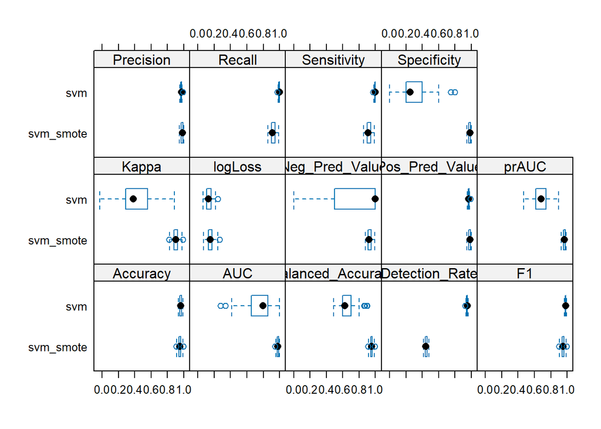

```r
# Boxplot for accuracy comparison
bwplot(results)
```

```r
# Pairwise comparisons
model_differences <- diff(results)
model_differences$statistics
```

```
$Accuracy
$Accuracy$svm.diff.svm_smote

    One Sample t-test

data:  x
t = 5.518, df = 99, p-value = 2.751e-07
alternative hypothesis: true mean is not equal to 0
95 percent confidence interval:
 0.00692505 0.01470197
sample estimates:
 mean of x
0.01081351



$AUC
$AUC$svm.diff.svm_smote

    One Sample t-test

data:  x
t = -12.799, df = 99, p-value < 2.2e-16
alternative hypothesis: true mean is not equal to 0
95 percent confidence interval:
 -0.2313962 -0.1692785
sample estimates:
 mean of x
-0.2003373



$Balanced_Accuracy
$Balanced_Accuracy$svm.diff.svm_smote

    One Sample t-test

data:  x
t = -30.912, df = 99, p-value < 2.2e-16
alternative hypothesis: true mean is not equal to 0
```

[output cut: 166 more lines]

```


$Specificity
$Specificity$svm.diff.svm_smote

    One Sample t-test

data:  x
t = -34.782, df = 99, p-value < 2.2e-16
alternative hypothesis: true mean is not equal to 0
95 percent confidence interval:
 -0.7107538 -0.6340379
sample estimates:
 mean of x
-0.6723958
```

## Visualize the confusion matrix tables

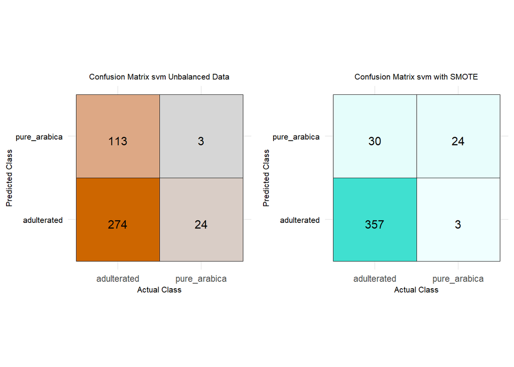

```r
p1<-ggplot(data = as.data.frame(test_svm_unmodified_CMtrx$table), aes(x = Reference, y = Prediction)) +
  geom_tile(aes(fill = Freq), color = "black") +
  geom_text(aes(label = sprintf("%0.0f", Freq)), vjust = 1,color = "black",size = 4) +
  scale_fill_gradient(low = "gray84", high = "darkorange3", name = "Frequency") +
  theme_minimal() +
  labs(x = "Actual Class", y = "Predicted Class", color = 'black',title = 'Confusion Matrix svm Unbalanced Data')+
  theme(
    legend.position =  "none",
    axis.text.y = element_text(color = "black",size = 8),
    axis.title.x  = element_text(size = 8),
    axis.title.y = element_text(size = 8),aspect.ratio = 1,
    plot.title = element_text(size = 8,hjust = 0.5))


p2<-ggplot(data = as.data.frame(test_svm_smote_CMtrx$table), aes(x = Reference, y = Prediction)) +
  geom_tile(aes(fill = Freq), color = "black") +
  geom_text(aes(label = sprintf("%0.0f", Freq)), vjust = 1,color = "black",size = 4) +
  scale_fill_gradient(low = "azure1", high = "turquoise", name = "Frequency") +
  theme_minimal() +
  labs(x = "Actual Class", y = "Predicted Class", color = 'black',title = 'Confusion Matrix svm with SMOTE')+
  theme(
    legend.position =  "none",
    axis.text.y = element_text(color = "black",size = 8),
    axis.title.x  = element_text(size = 8),
    axis.title.y = element_text(size = 8),aspect.ratio = 1,
    plot.title = element_text(size = 8,hjust = 0.5))

grid.arrange(p1,p2, nrow =1)
```

## ROC Curve

```r
#SMOTE data
roc_curve <- roc(test_merged_smote_Preprocessed$binary_class, as.numeric(test_svm_smote))
```

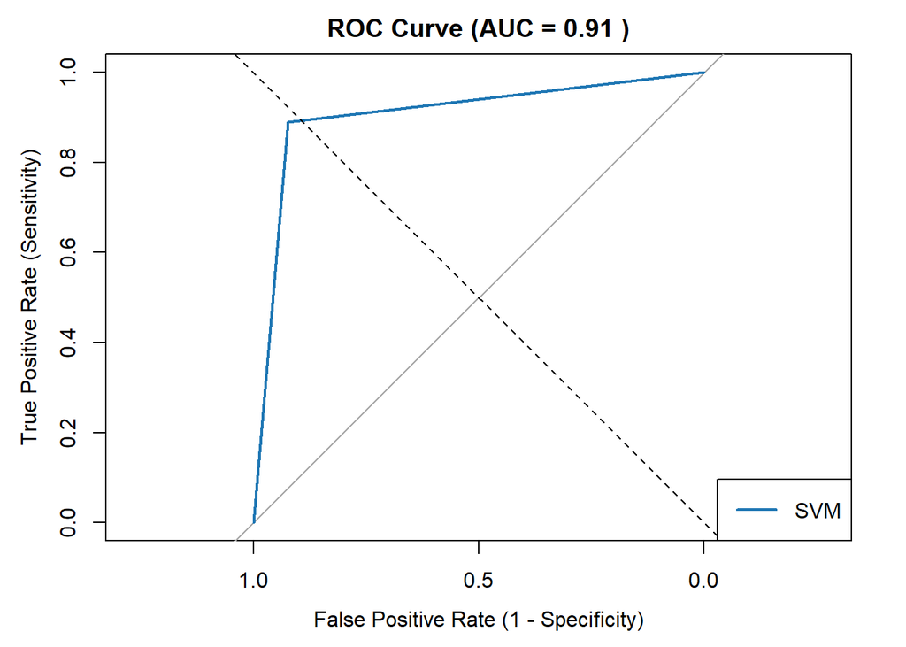

```r
auc_value <- auc(roc_curve)
plot(roc_curve, col = '#1f77b4', lwd = 2,
     main = paste("ROC Curve (AUC =", round(auc_value, 2), ")"),
     xlab = "False Positive Rate (1 - Specificity)",
     ylab = "True Positive Rate (Sensitivity)")
abline(a = 0, b = 1, lty = 2, col = "black")
legend("bottomright", legend = c("SVM"), col = '#1f77b4', lwd = 2)
```